# Twitter Analysis 2016

## Introduction

In this project, we would like to understand what people’s attitude to libraries and what do they say about libraries in 2016 (from 01-01-2016 to 12-31-2016). We used key twitter search terms “library”, “libraries”, “librarian”, “librarians”, “librarianship”, and scrapped all tweets from twitter. Our tweets dataset contains 97199 observations.

We cleaned the data by 1. changed all text into lower cases 2. removed stopwords suchs as “a”, “the”, etc. We also took “library”, “libraries”, “librarian”, “librarians” out from the text because they are our key searching words 3. removed punctuation 4. remove numbers 5. remove stem words (A **stem** is a part of word, e.g de-, -(e)d, -(e)s.)

We also calculated the sentiment score to each tweets. A positive score means positive sentiment and a negative score means negative sentiment.

## The 20 most common words for all tweets

```
##          word  freq
## book     book 10889
## new       new  6320
## get       get  5093
## public public  4767
## today   today  4244
## school school  4124
## read     read  4120
## like     like  3138
## one       one  3082
## make     make  2974
## day       day  2967
## open     open  2875
## free     free  2868
## come     come  2811
## see       see  2700
## love     love  2622
## look     look  2579
## need     need  2373
## time     time  2352
## year     year  2324
```

The WordCloud of the first 150 most common words for all tweets

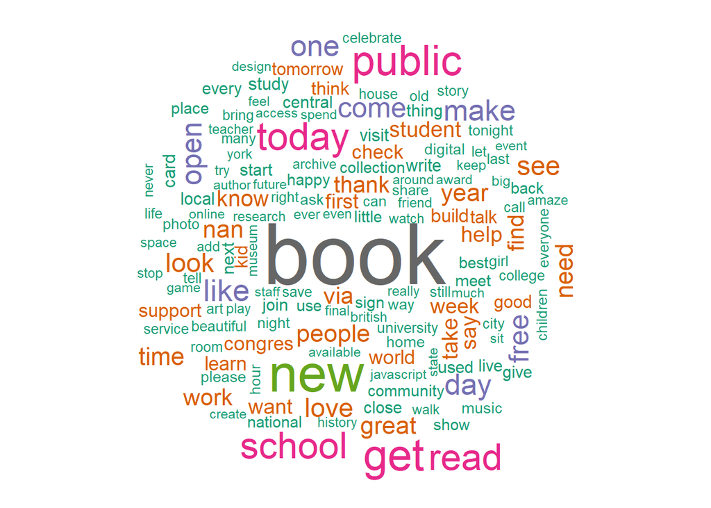

```r
cor.special <- brewer.pal(8,"Dark2")
d.1 <- d[1:150,]
wordcloud(d.1$word, d.1$freq, scale=c(5,.48),  # make a word cloud
          colors=cor.special, ordered.colors=F)
```

## Most common adjective words

We also would like to analyze the most common adjectives in the tweets to see if we can have a better understanding of people’s attitudes to libraries.

The 20 most common adjective words

```
##          word freq
## 121       new 6320
## 144    public 4767
## 128      open 2875
## 68       free 2868
## 79      great 2321
## 75       good 1430
## 105     local 1344
## 25    central 1242
## 104      live 1218
## 103    little 1122
## 81      happy 1112
## 120  national 1110
## 42    digital 1026
## 100      last  985
## 127       old  975
## 16  beautiful  974
## 112      many  847
## 22    british  814
## 65      final  803
## 17        big  795
```

The Word Cloud of the 150 most common adjective words

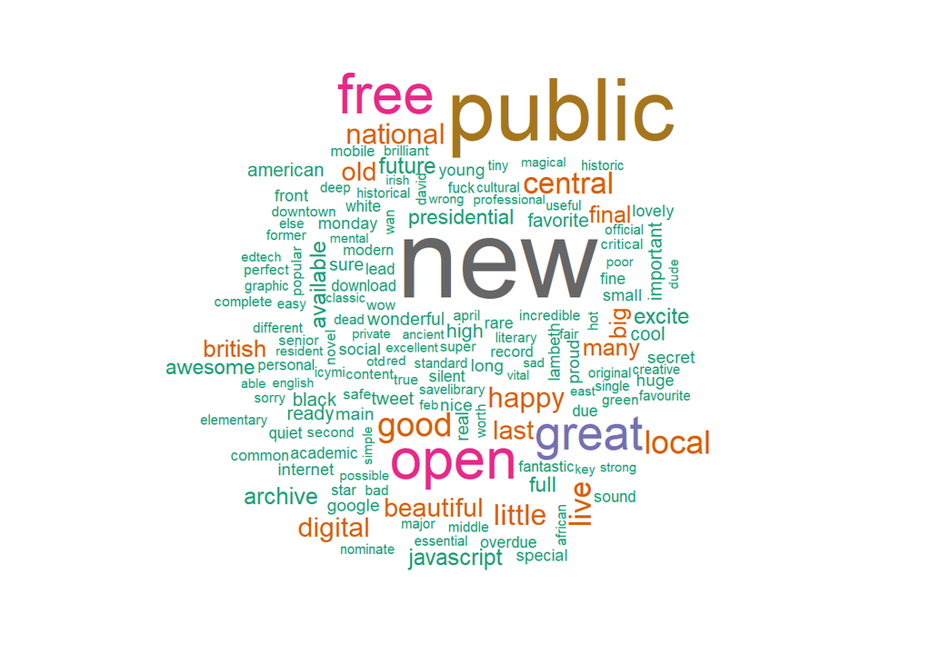

```r
cor.special <- brewer.pal(8,"Dark2")
adj.cloud <- adj.all[1:150,]
wordcloud(adj.cloud$word, adj.cloud$freq, scale=c(5,.5),  # make a word cloud
          colors=cor.special, ordered.colors=F)
```

## Positive vs Negative

We estimated the sentiment of each tweets and score them. A positive sentiment_polarity means the tweet is a positive one. A negative_polarity means the tweet is a negative one. We classified the tweets into positive and negative, and analyzed both positive and negative tweets below.

### Analysis 1: LASSO

Use LASSO to analyze the relationship between each word and sentiment of people.

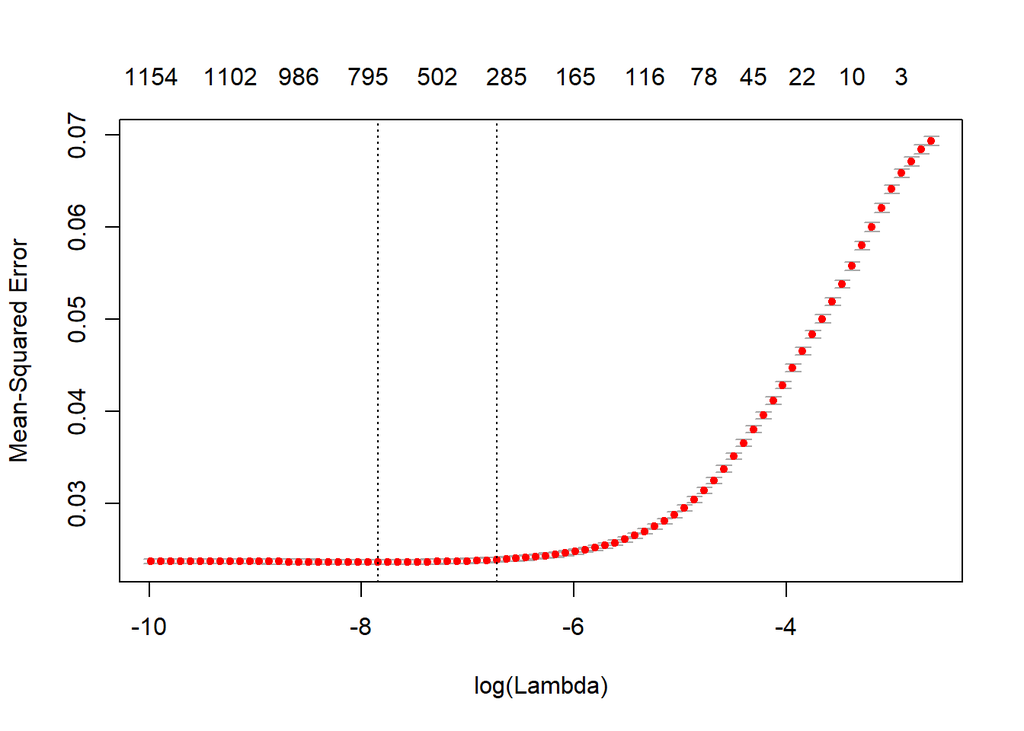

Prediction Error is small (0.023), so the model is acceptable.

The histogram shows the distribution of the coefficients (The distribution of words that have positive or negative effects on sentiments) From the histogram, we have large amount of words that are around 0, meaning neutural word. Number of positive coef’s are slightly more than that of negative words.

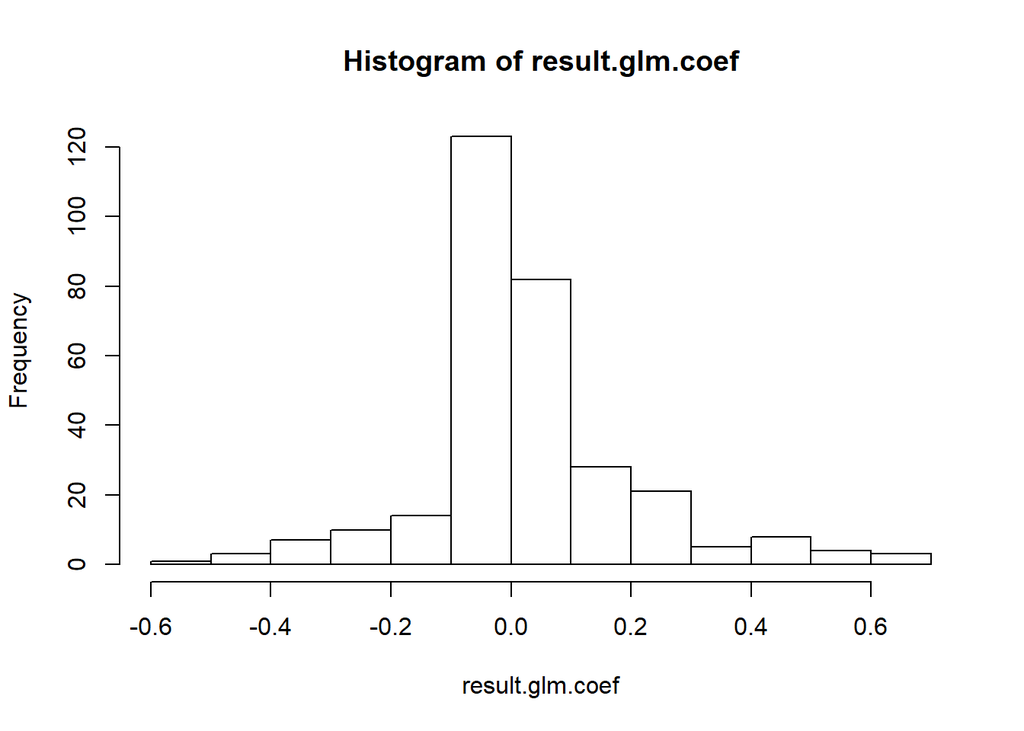

#### Postive word cloud

Extract words with postitive coefficients (words that have positive corelations to sentiments) The following words are 20 words with most positive coef’s.

```
##    perfect  excellent   greatest       best    awesome  beautiful
##     0.6396     0.6321     0.6270     0.5926     0.5559     0.5291
##  wonderful incredible        win      proud  brilliant      happy
##     0.5106     0.4959     0.4721     0.4575     0.4534     0.4464
##    welcome      great        lol       good    popular       fair
##     0.4417     0.4322     0.4287     0.3547     0.3410     0.3331
##       nice       kind
##     0.3148     0.3070
```

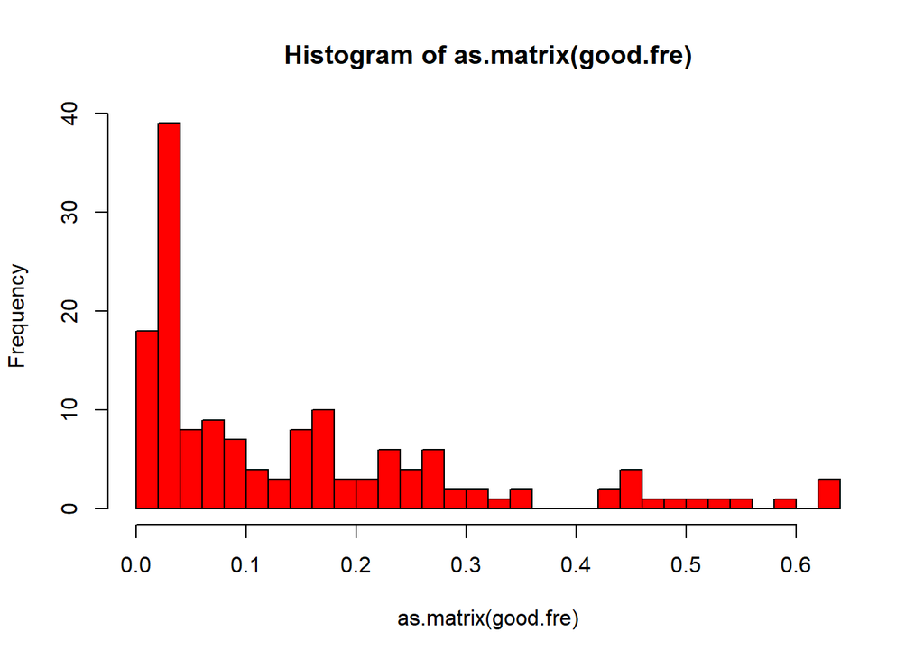

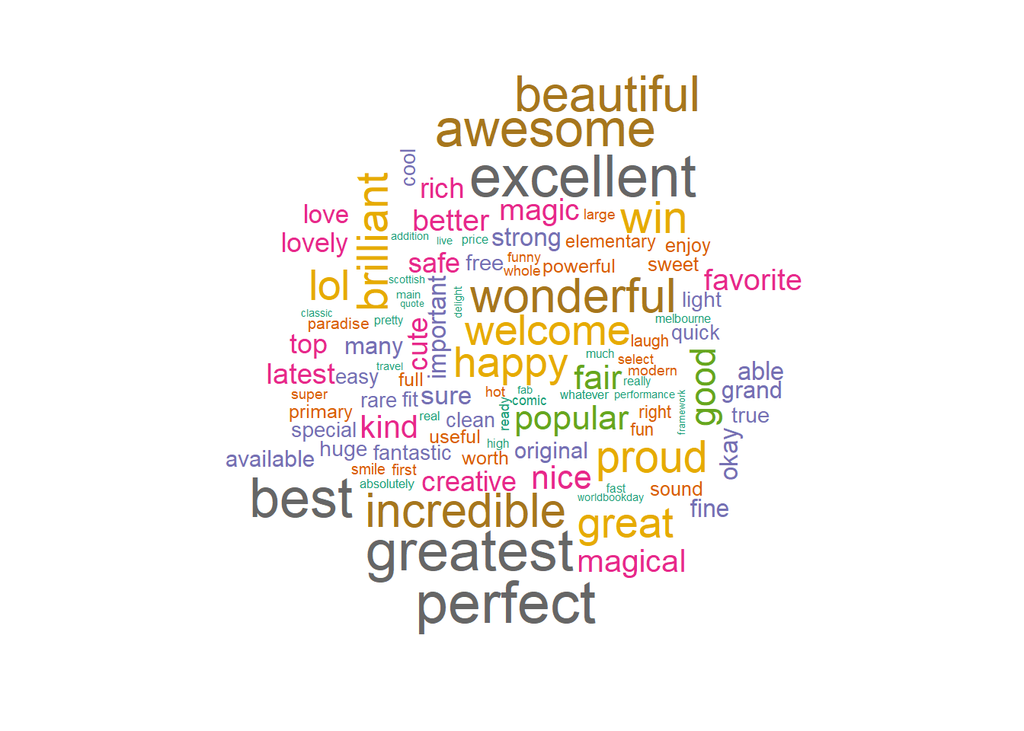

#### Negative word cloud

Similarly to the negative coef’s which is positively correlated to be a tweet with negative sentiment. The following words are 20 words with most negative coef’s.

```
##   base   hate    bad  crazy random  wrong    sad   fail  weird  sorry
## 0.5595 0.4506 0.4421 0.4079 0.3564 0.3542 0.3455 0.3402 0.3192 0.3145
## secret behind   game common   fuck  alien   poor   mean   late  least
## 0.3102 0.2856 0.2606 0.2572 0.2397 0.2375 0.2369 0.2211 0.2207 0.2088
```

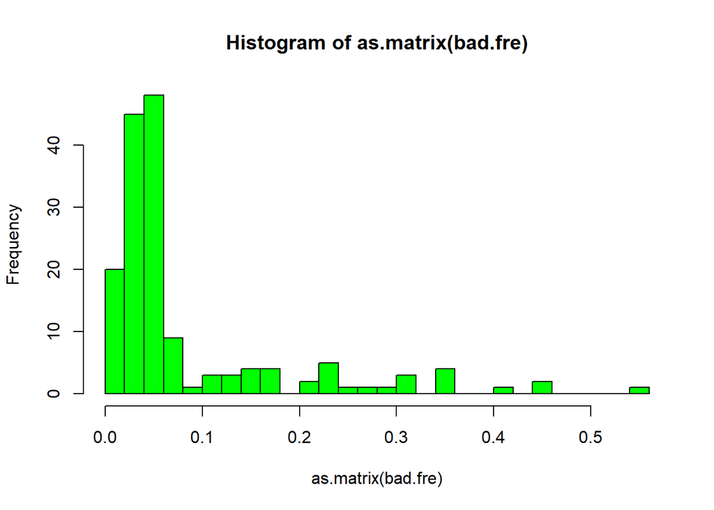

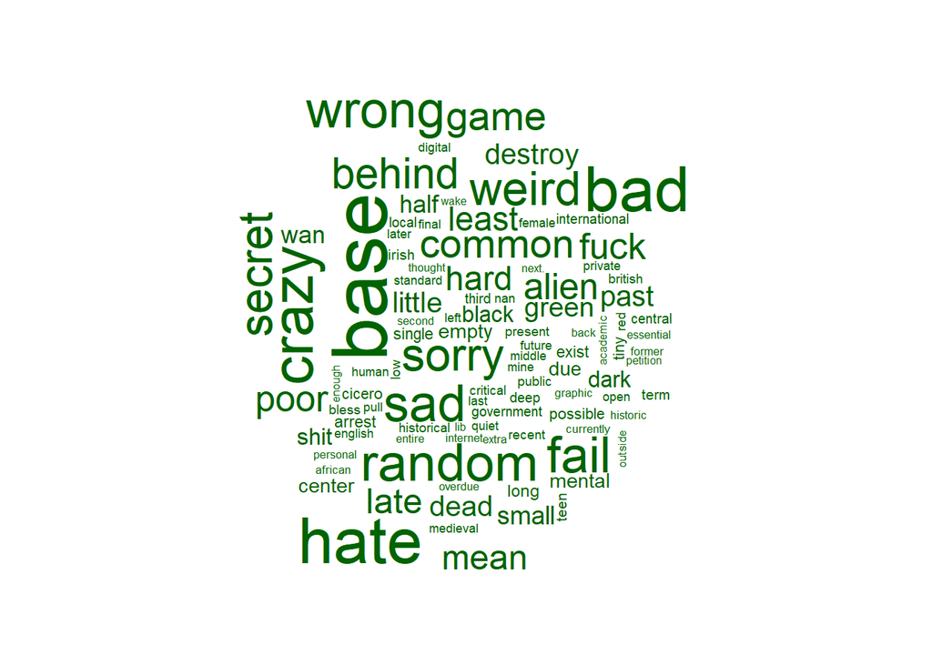

#### Put two clouds together

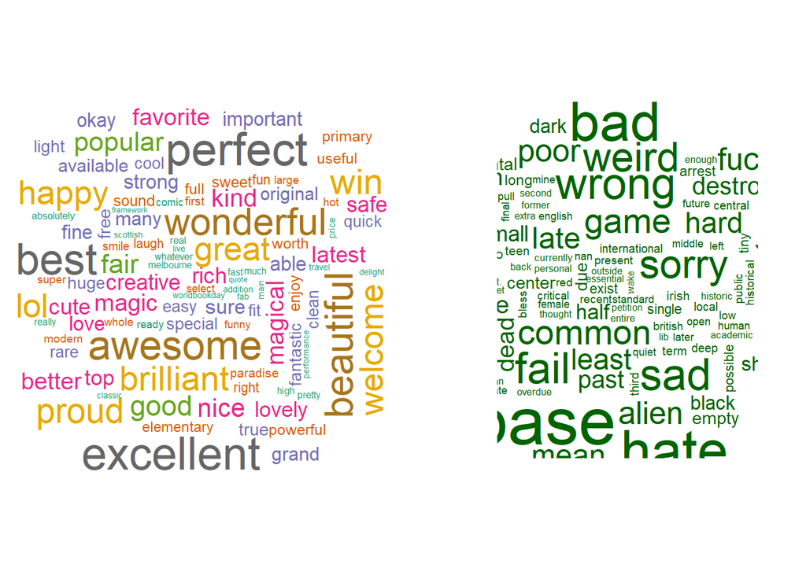

## Sentiment vs Month

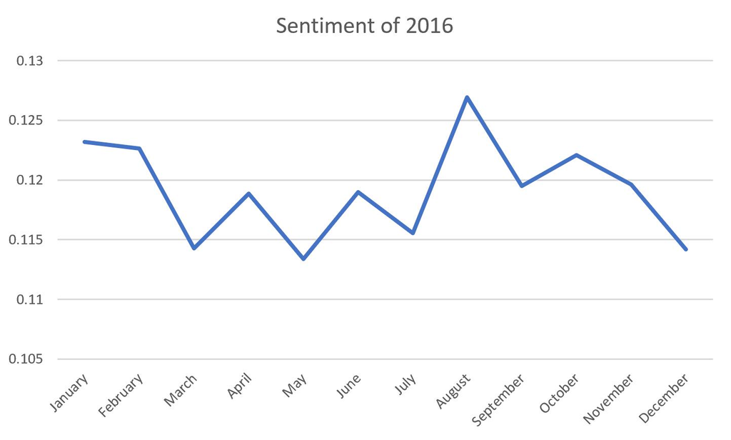

```r
sent <- data %>% group_by(Month) %>% summarize(sent_mean = mean(sentiment_polarity))
sent
```

```
## # A tibble: 12 x 2
##    Month     sent_mean
##    <chr>         <dbl>
##  1 April         0.119
##  2 August        0.127
##  3 December      0.114
##  4 February      0.123
##  5 January       0.123
##  6 July          0.116
##  7 June          0.119
##  8 March         0.114
##  9 May           0.113
## 10 November      0.120
## 11 October       0.122
## 12 September     0.120
```

```r
summary(sent$sent_mean)
```

```
##    Min. 1st Qu.  Median    Mean 3rd Qu.    Max.
##  0.1134  0.1152  0.1192  0.1191  0.1222  0.1269
```

## Pie chart of percentage of sentiment

From the following pie chart, we can tell 41.95% people have postitive feeling about library, 48.16% have neutural feeling and 9.89% have negative feelings.

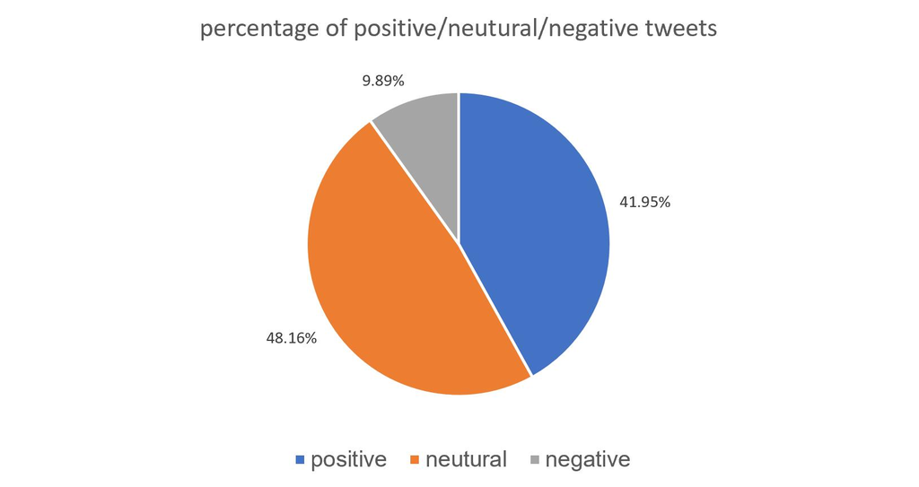